# FIREpHly

Erik Larsen

2025-01-22

# Overview

This markdown was developed to formally document the data analysis of FIRE-pHly data for **Dr. Martha Bhattacharya’s lab** at the **University of Arizona** for the endolysosomal paper under revision (2025-02-10).

Please open the `FIREpHly.nb.html` file directly to peruse code.

Until a container is built, the `R version` used was **R 4.3.2** with the packages installed below

### Set up Environment

#### Attach packages

```r
packages <- c(#'TMEM',
               'Endo',
              'tidyverse',
              'ggplot2',
              'ggtext',
              # 'readr',
              'ggsignif',
              'emmeans',
              'broom',
              'DT'
              )
for ( package in packages ) {
  if (!require(package, character.only = T)) {
    install.packages(package)
    library(package, character.only = T)
  }
}
```

# Read in FIRE-pHly Data

**Load the FIRE-pHly data from separate sheets (not shown)**

```r
data(FIREpHly_WT)
data(FIREpHly_Mut)
```

### Wrangle the WT Data

**Re-arrange the data to make it analyzable (code not shown in md)**

### Wrangle the MUT Data

**Re-arrange the data to make it analyzable (code not shown in md)**

# Visualize

**Investigate the distributions of measured variables**

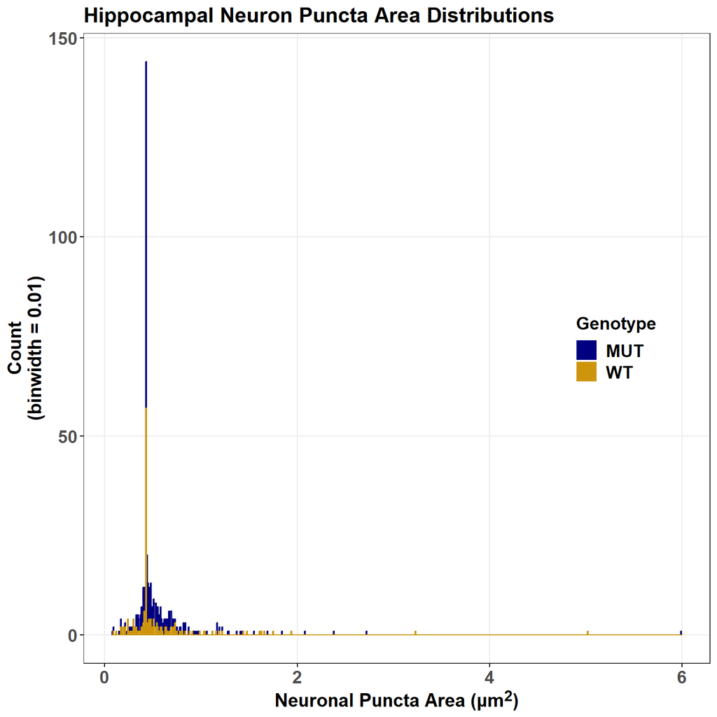

**Crop to better-discern differences in the majority of the data**

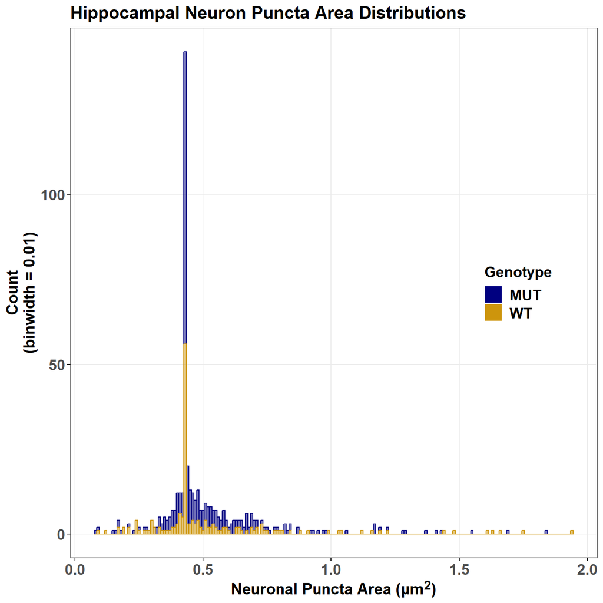

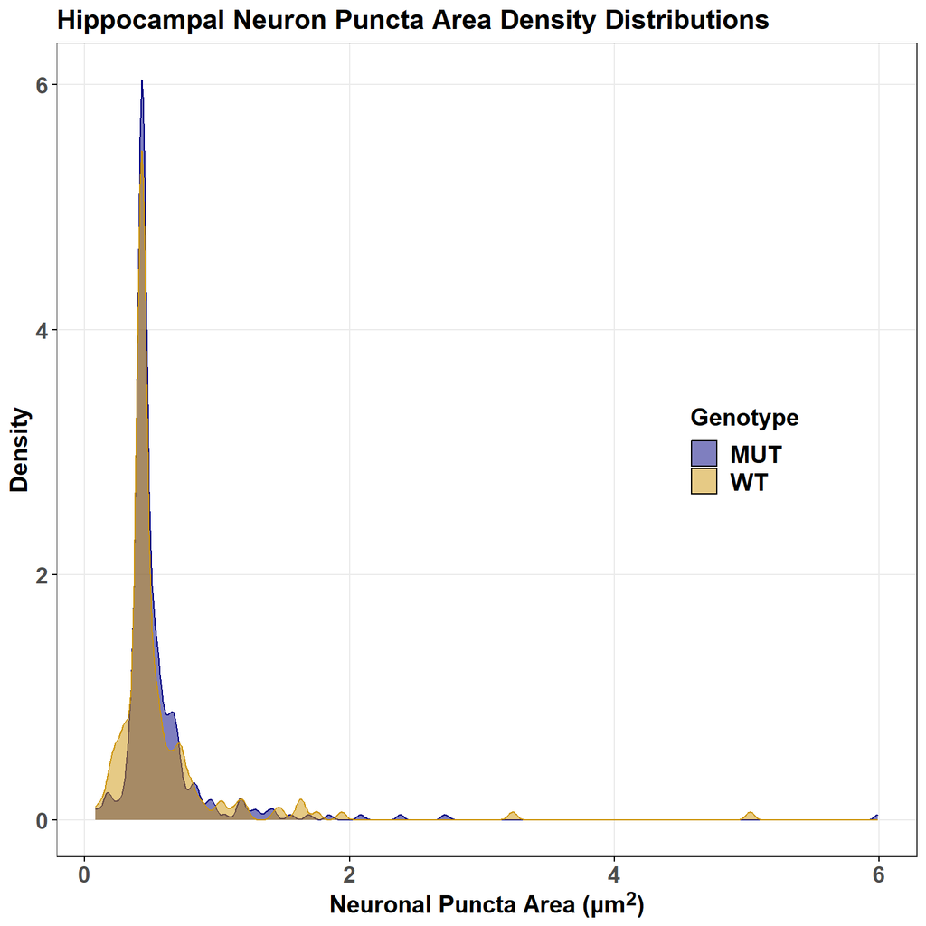

**Crop to better-discern differences in the majority of the data**

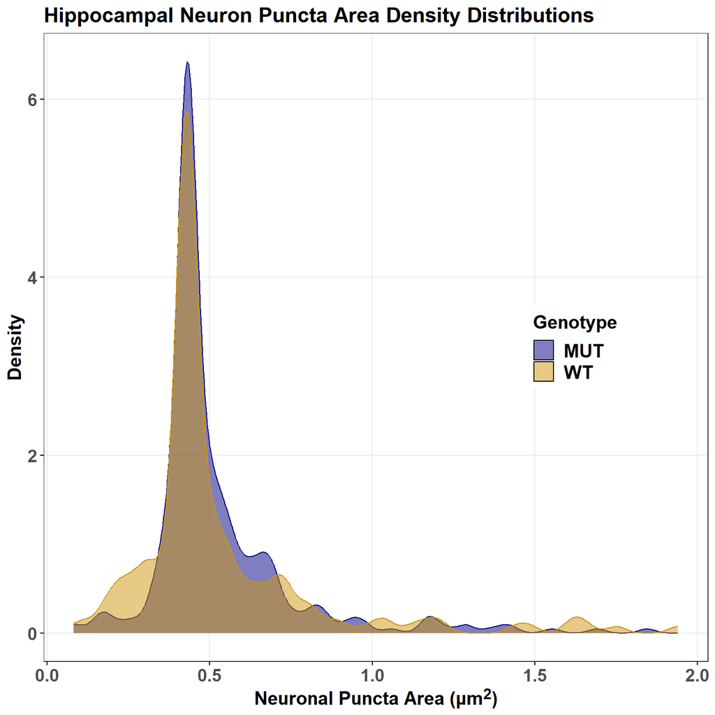

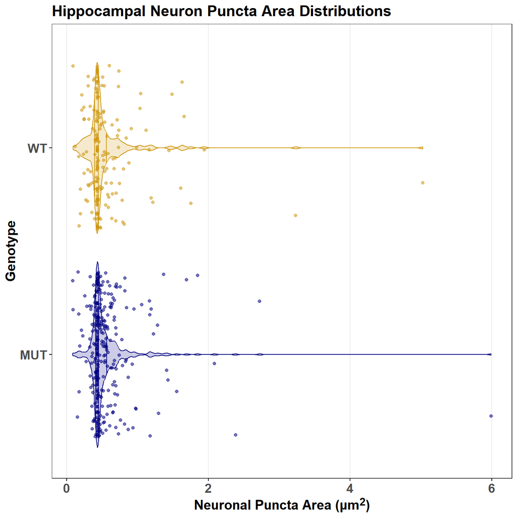

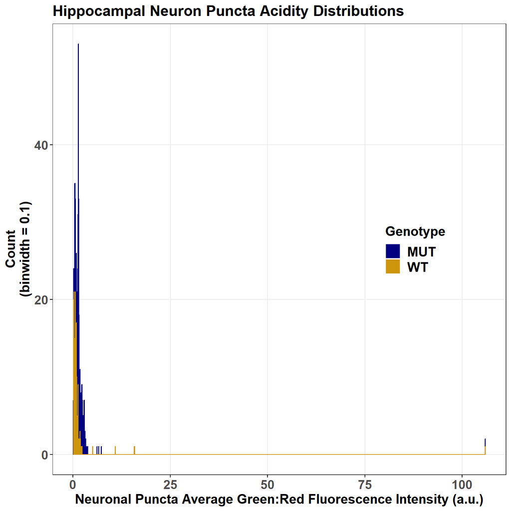

**Crop to better-discern differences in the majority of the data**

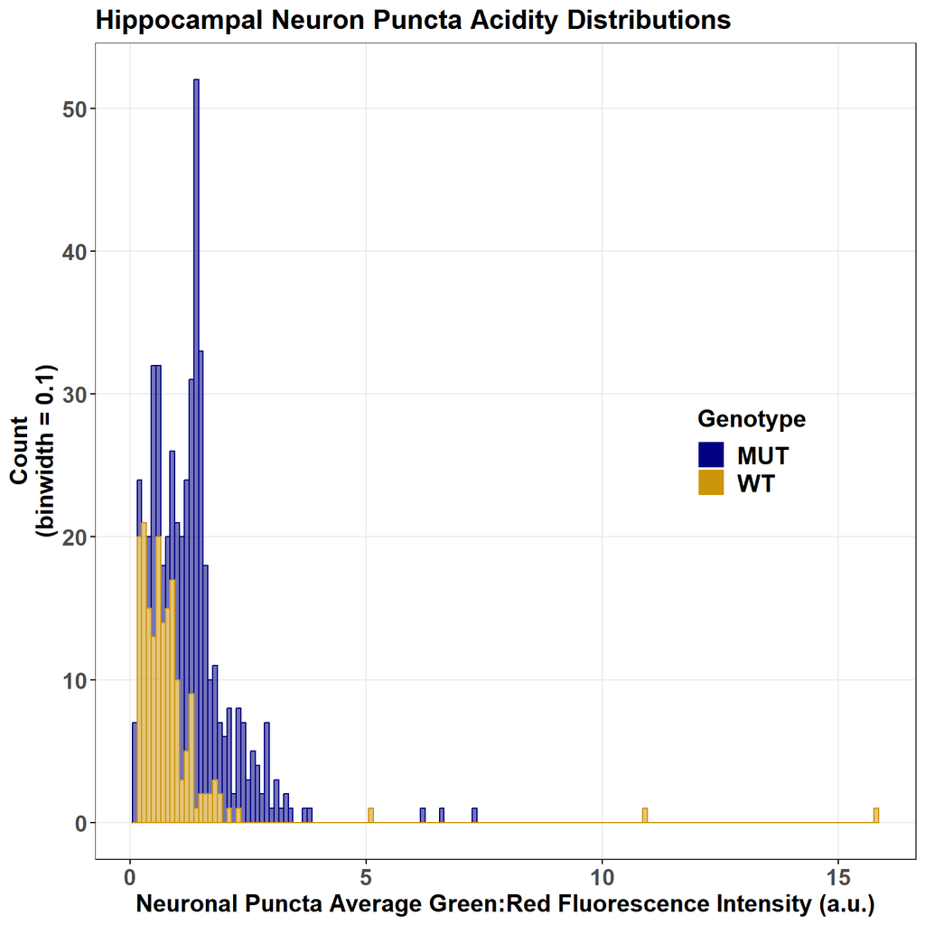

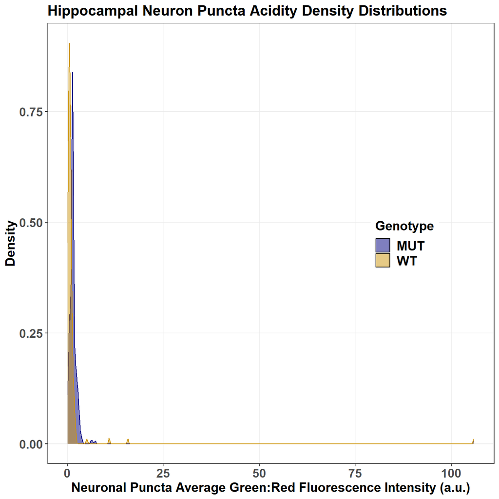

**Crop to better-discern differences in the majority of the data**

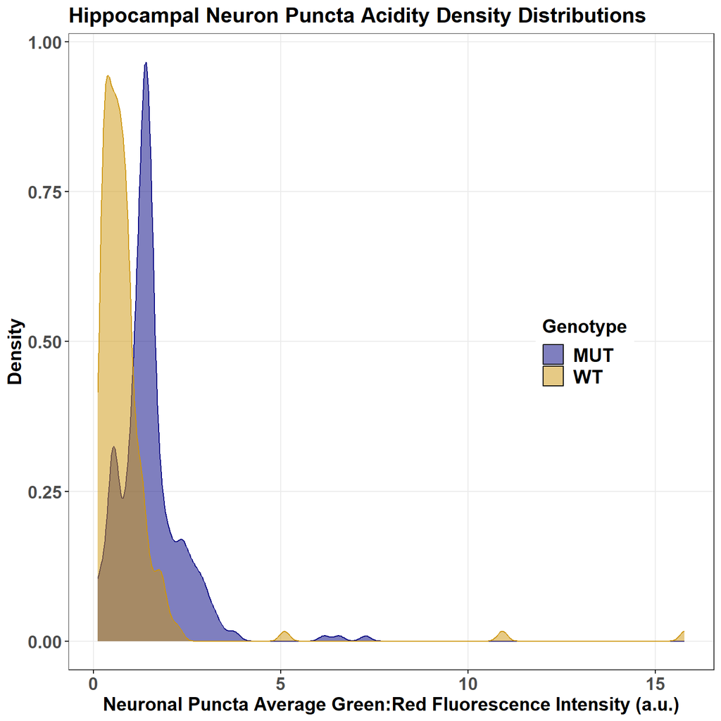

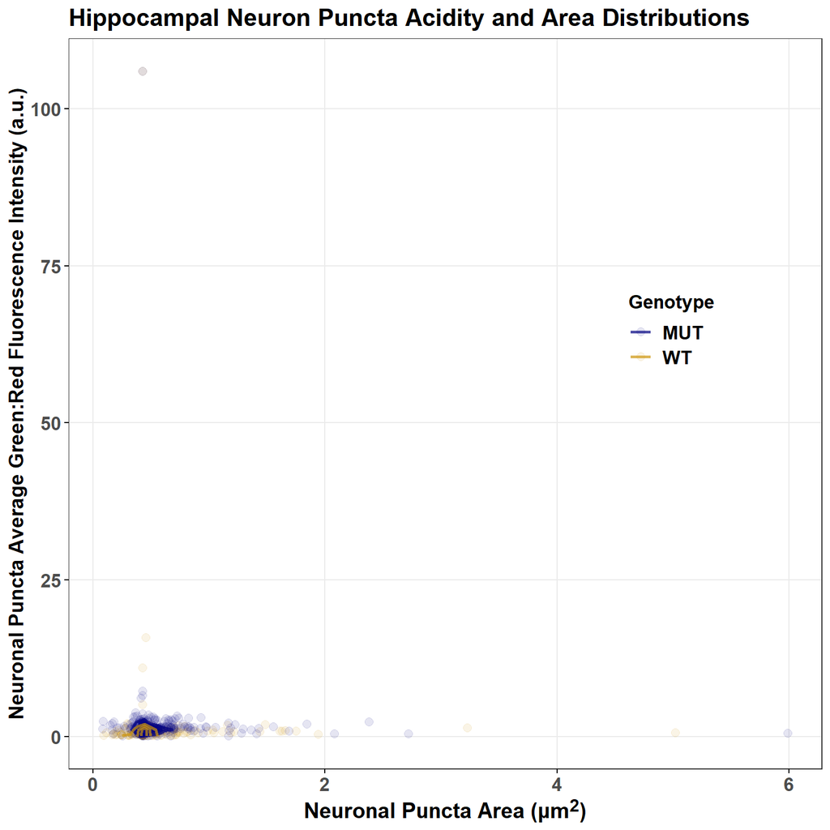

**Crop to better-discern differences in the majority of the data**

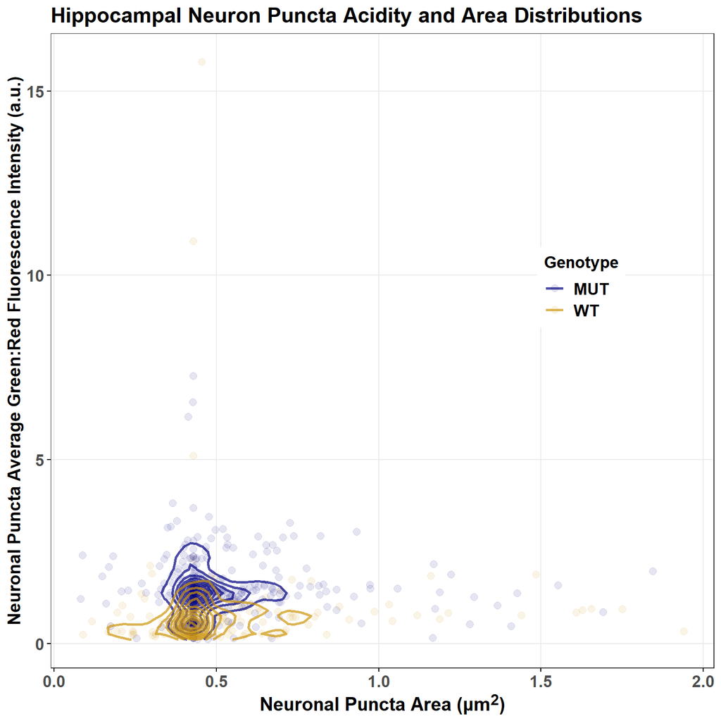

# Statistics

**Perform weighted linear regressions on puncta data to appropriately account for experimenter bias, inter-mouse variability, and (genotypic) inter-puncta variability**

### Puncta Acidity

```
##
## Call:
## lm(formula = Cell_Avg_Puncta_GreenRedRatio ~ Genotype, data = Puncta_avg_acidity,
##     weights = mouse_puncta_w)
##
## Weighted Residuals:
##      Min       1Q   Median       3Q      Max
## -0.85269 -0.36344 -0.05489  0.14189  1.12221
##
## Coefficients:
##             Estimate Std. Error t value Pr(>|t|)
## (Intercept)   1.4302     0.1643   8.703 2.08e-08 ***
## GenotypeWT   -0.7026     0.2324  -3.023  0.00647 **
## ---
## Signif. codes:  0 '***' 0.001 '**' 0.01 '*' 0.05 '.' 0.1 ' ' 1
##
## Residual standard error: 0.5197 on 21 degrees of freedom
## Multiple R-squared:  0.3032, Adjusted R-squared:   0.27
## F-statistic: 9.139 on 1 and 21 DF,  p-value: 0.006472
```

**Check shaprio-wilk**

```
##
##  Shapiro-Wilk normality test
##
## data:  as.numeric(summary(puncta_acidity_lm)$residuals)
## W = 0.95054, p-value = 0.3003
```

### Puncta Area

```
##
## Call:
## lm(formula = Cell_Avg_Puncta_Area ~ Genotype, data = Puncta_avg_area,
##     weights = mouse_puncta_w)
##
## Weighted Residuals:
##      Min       1Q   Median       3Q      Max
## -0.17678 -0.09906 -0.02857  0.08363  0.30133
##
## Coefficients:
##             Estimate Std. Error t value Pr(>|t|)
## (Intercept)  0.55752    0.04490  12.418 3.86e-11 ***
## GenotypeWT   0.01227    0.06349   0.193    0.849
## ---
## Signif. codes:  0 '***' 0.001 '**' 0.01 '*' 0.05 '.' 0.1 ' ' 1
##
## Residual standard error: 0.142 on 21 degrees of freedom
## Multiple R-squared:  0.001775,   Adjusted R-squared:  -0.04576
## F-statistic: 0.03734 on 1 and 21 DF,  p-value: 0.8486
```

**Check shapiro-wilk**

```
##
##  Shapiro-Wilk normality test
##
## data:  as.numeric(summary(puncta_area_lm)$residuals)
## W = 0.92732, p-value = 0.09572
```

### Puncta Number

```
##
## Call:
## lm(formula = puncta_n ~ Genotype, data = Puncta_n, weights = mouse_puncta_w)
##
## Weighted Residuals:
##     Min      1Q  Median      3Q     Max
## -54.201 -20.327  -1.051  27.863  52.679
##
## Coefficients:
##             Estimate Std. Error t value Pr(>|t|)
## (Intercept)   24.692      2.402  10.281 1.19e-09 ***
## GenotypeWT    -6.492      3.165  -2.051    0.053 .
## ---
## Signif. codes:  0 '***' 0.001 '**' 0.01 '*' 0.05 '.' 0.1 ' ' 1
##
## Residual standard error: 34.28 on 21 degrees of freedom
## Multiple R-squared:  0.1669, Adjusted R-squared:  0.1272
## F-statistic: 4.207 on 1 and 21 DF,  p-value: 0.05295
```

**Check shapiro-wilk**

```
##
##  Shapiro-Wilk normality test
##
## data:  as.numeric(summary(puncta_n_lm)$residuals)
## W = 0.95369, p-value = 0.3484
```

### Cell Body Area

```r
  ## Welch's t test
t.test(x = c(Puncta_data |>
               dplyr::group_by(Genotype, cell_num) |>
               dplyr::distinct(Cell_Body_Area) |>
               dplyr::ungroup() |>
               dplyr::filter(Genotype == "WT") |>
               dplyr::select(Cell_Body_Area) |>
               unlist() |> as.numeric()
),
y = c(Puncta_data |>
        dplyr::group_by(Genotype, cell_num) |>
        dplyr::distinct(Cell_Body_Area) |>
        dplyr::ungroup() |>
        dplyr::filter(Genotype == "MUT") |>
        dplyr::select(Cell_Body_Area) |>
        unlist() |> as.numeric()
),
alternative = 'two.sided', var.equal = F)
```

```
##
##  Welch Two Sample t-test
##
## data:  c(as.numeric(unlist(dplyr::select(dplyr::filter(dplyr::ungroup(dplyr::distinct(dplyr::group_by(Puncta_data, Genotype, cell_num), Cell_Body_Area)), Genotype == "WT"), Cell_Body_Area)))) and c(as.numeric(unlist(dplyr::select(dplyr::filter(dplyr::ungroup(dplyr::distinct(dplyr::group_by(Puncta…
## t = -2.2192, df = 20.999, p-value = 0.03762
## alternative hypothesis: true difference in means is not equal to 0
## 95 percent confidence interval:
##  -174.804621   -5.676421
## sample estimates:
## mean of x mean of y
##  124.1645  214.4051
```

**Check shapiro-wilk**

```r
  ## Examine residuals
    ## extract from lm (~ same as Welch's t test)
cell_area_lm <- lm(data = Puncta_data |>
                     dplyr::group_by(Genotype, cell_num) |>
                     dplyr::distinct(Cell_Body_Area) |>
                     dplyr::ungroup(),
                   formula = Cell_Body_Area ~ Genotype)

  ## Shapiro.wilk
shapiro_cell_area <- shapiro.test(
  summary(cell_area_lm)$residuals |> as.numeric())

shapiro.test(summary(cell_area_lm)$residuals |> as.numeric())
```

```
##
##  Shapiro-Wilk normality test
##
## data:  as.numeric(summary(cell_area_lm)$residuals)
## W = 0.90911, p-value = 0.03913
```

**Significant. Show the residuals**

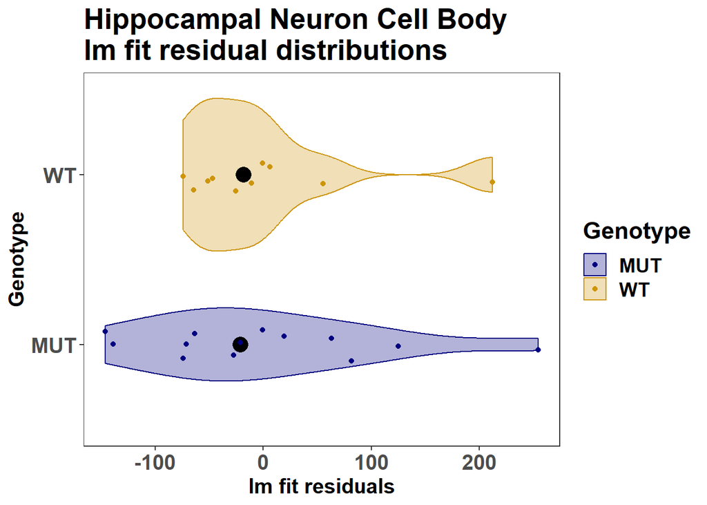

```r
  ## Cell Body area residuals distributions
Puncta_data |>
  dplyr::group_by(Genotype, cell_num) |>
  dplyr::distinct(Cell_Body_Area) |>
  dplyr::ungroup() |>
  dplyr::mutate(Cell_Body_Area = as.numeric(Cell_Body_Area),
                resids = lm(data = Puncta_data |>
                              dplyr::group_by(Genotype, cell_num) |>
                              dplyr::distinct(Cell_Body_Area) |>
                              dplyr::ungroup(),
                            formula = as.numeric(Cell_Body_Area) ~ Genotype
                            )$residuals |> as.numeric()
                ) |>
  ggplot(aes(x = resids, y = Genotype, color = Genotype, fill = Genotype)) +
  geom_violin(alpha = 0.3) +
  stat_summary(fun.y = 'median',
               geom = 'point',
               color = 'black',
               size = 5,
               show.legend = FALSE) +
  guides(alpha = 'none') +
  geom_jitter(data = Puncta_data |>
                dplyr::group_by(Genotype, cell_num) |>
                dplyr::distinct(Cell_Body_Area) |>
                dplyr::ungroup() |>
                dplyr::mutate(
                  Cell_Body_Area = as.numeric(Cell_Body_Area),
                  resids = lm(data = Puncta_data |>
                                dplyr::group_by(Genotype, cell_num) |>
                                dplyr::distinct(Cell_Body_Area) |>
                                dplyr::ungroup(),
                              formula = as.numeric(Cell_Body_Area) ~ Genotype
                              )$residuals |> as.numeric()
                ),
              aes(x = resids,
                  y = Genotype), alpha = 1, width = 0.01, height = 0.1) +
  labs(title = 'Hippocampal Neuron Cell Body\nlm fit residual distributions',
       x = 'lm fit residuals',
       y = 'Genotype') +
  theme_bw() +
  theme(title = element_text(face = 'bold', size = 17),
        axis.title = element_text(face = 'bold', size = 15),
        axis.text = element_text(face = 'bold', size = 15),
        panel.grid = element_blank(),
        legend.text = element_text(face = 'bold', size = 14)
  ) +
  guides(alpha = 'none') +
  scale_color_manual(values = c('navy', 'darkgoldenrod3')) +
  scale_fill_manual(values = c('navy', 'darkgoldenrod3'))
```

**What’s the shape of the dv?**

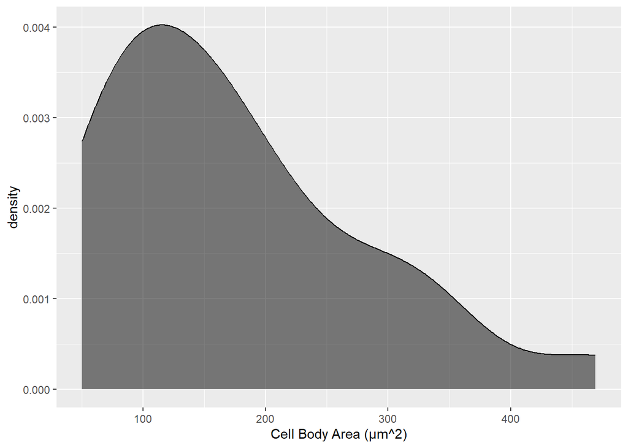

```r
Puncta_data |> dplyr::distinct(Cell_Body_Area) |>
  ggplot(aes(x = as.numeric(Cell_Body_Area))) +
  geom_density(fill = 'black', alpha = 0.5) +
  labs(x = paste0('Cell Body Area (', '\U03BCm^2', ')'))
```

```r
  ## GLM
cell_area_glm <- glm(data = Puncta_data |>
                       dplyr::group_by(Genotype, cell_num) |>
                       dplyr::distinct(Cell_Body_Area) |>
                       dplyr::ungroup(),
                     formula = as.numeric(Cell_Body_Area) ~ Genotype,
                     family = 'Gamma')

summary(cell_area_glm)
```

```
##
## Call:
## glm(formula = as.numeric(Cell_Body_Area) ~ Genotype, family = "Gamma",
##     data = dplyr::ungroup(dplyr::distinct(dplyr::group_by(Puncta_data,
##         Genotype, cell_num), Cell_Body_Area)))
##
## Coefficients:
##              Estimate Std. Error t value Pr(>|t|)
## (Intercept) 0.0046641  0.0007643   6.102 4.69e-06 ***
## GenotypeWT  0.0033898  0.0016878   2.008   0.0576 .
## ---
## Signif. codes:  0 '***' 0.001 '**' 0.01 '*' 0.05 '.' 0.1 ' ' 1
##
## (Dispersion parameter for Gamma family taken to be 0.3491339)
##
##     Null deviance: 8.1667  on 22  degrees of freedom
## Residual deviance: 6.5386  on 21  degrees of freedom
## AIC: 272.89
##
## Number of Fisher Scoring iterations: 5
```

**Is there a relationship between cell body size and puncta size?** **Do the genotypes differ?**

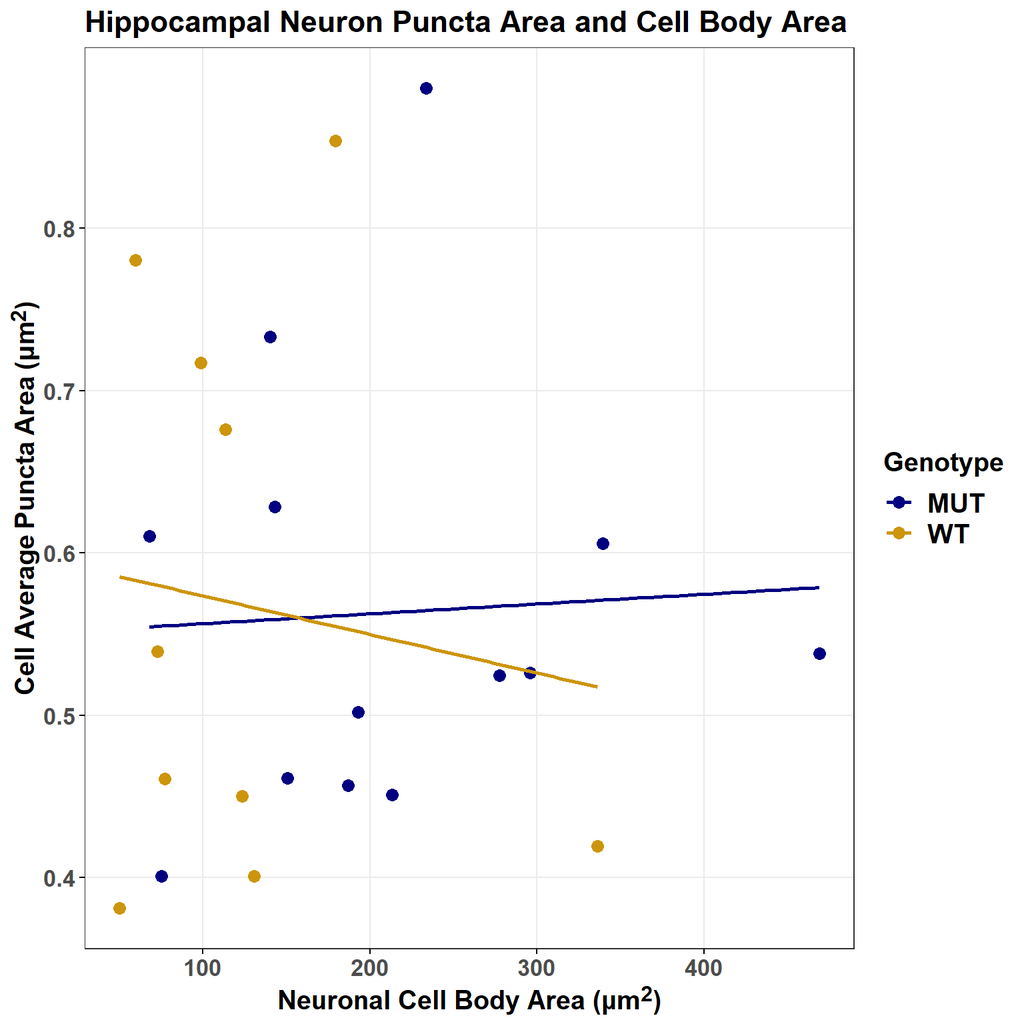

# Stats Plots

**Visualize the statistical test results**

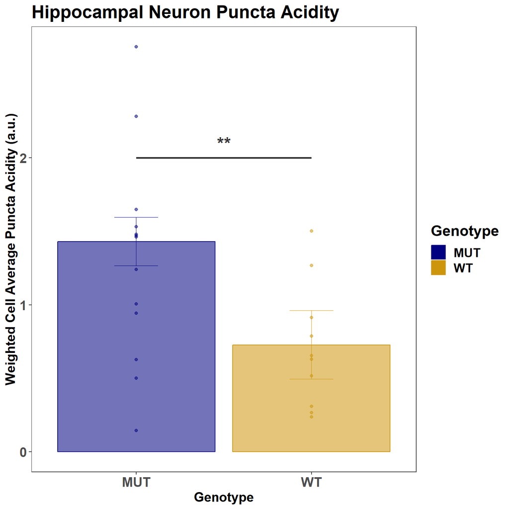

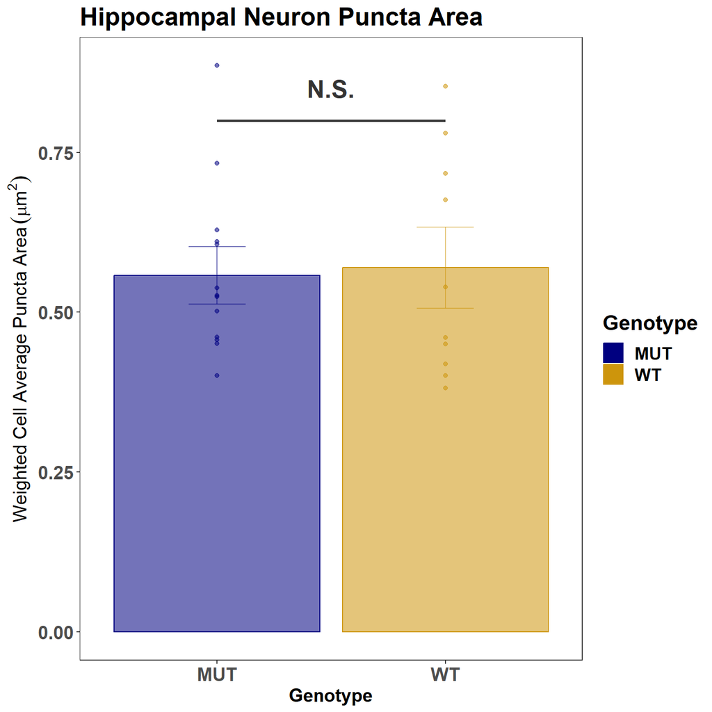

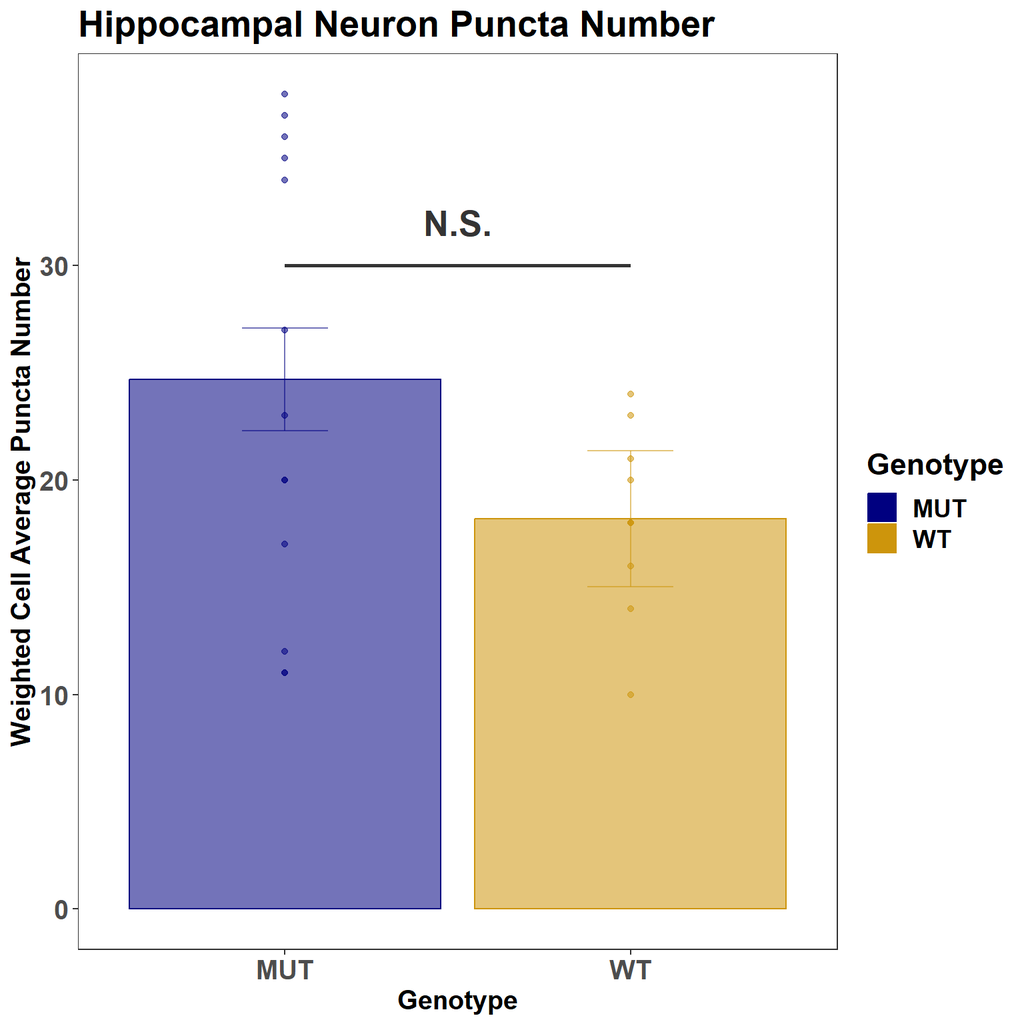

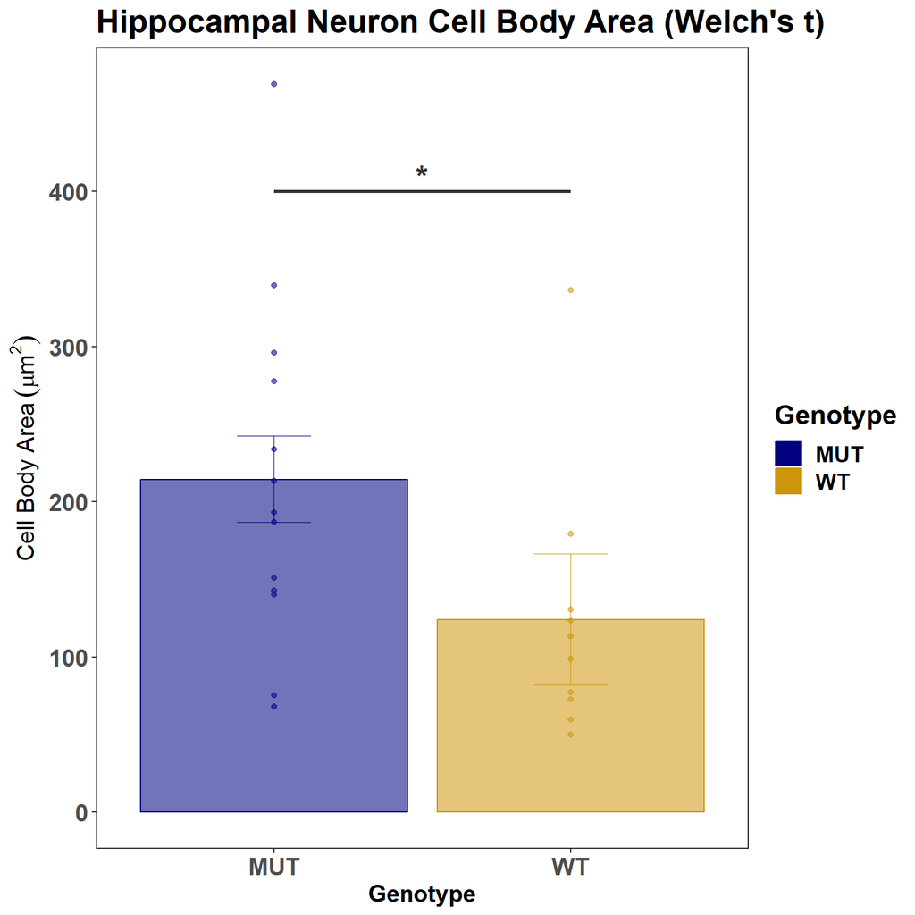

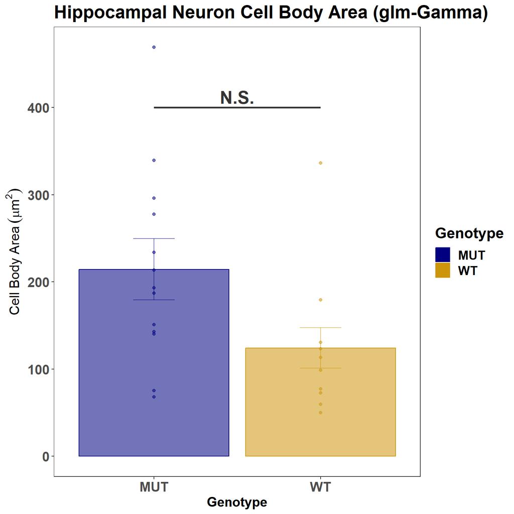

# Results Tables

### Tidied Puncta Data

|  | Genotype | cell_num | Puncta_ID | Puncta_Circularity | Puncta_Area | Intra_Puncta_Green_Intensity | Intra_Puncta_Red_Intensity | GreenRed_Ratio | Cell_Body_Area | Puncta_Count | Cell_Avg_Puncta_Green_Intensity | Cell_Avg_Puncta_Red_Intensity | Puncta_Count_Normalized_to_Cell_Area | Cell_Avg_Puncta_GreenRedRatio |
| --- | --- | --- | --- | --- | --- | --- | --- | --- | --- | --- | --- | --- | --- | --- |
| 1 | WT | 1 | 1 | 0.99128125187961003 | 0.428966883293556 | 39.907849829351498 | 32.699658703071599 | 1.2204362801377744 | 123.349207683442 | 10 | 41.469593495935001 | 63.452032520325098 | 8.1070646401422408 | 0.653558158009381 |
| 2 | WT | 1 | 2 | 0.99128125187961003 | 0.428966883293556 | 39.382252559726901 | 43.010238907849804 | 0.91564830979209566 | 123.349207683442 | 10 | 41.469593495935001 | 63.452032520325098 | 8.1070646401422408 | 0.653558158009381 |
| 3 | WT | 1 | 3 | 0.99128125187961003 | 0.428966883293556 | 48.0068259385665 | 112.39590443685999 | 0.42712255556905121 | 123.349207683442 | 10 | 41.469593495935001 | 63.452032520325098 | 8.1070646401422408 | 0.653558158009381 |
| 4 | WT | 1 | 4 | 0.91033390158521799 | 0.80229983633061 | 41.343065693430603 | 56.370437956204299 | 0.73341750024278929 | 123.349207683442 | 10 | 41.469593495935001 | 63.452032520325098 | 8.1070646401422408 | 0.653558158009381 |
| 5 | WT | 1 | 5 | 0.99128125187961003 | 0.428966883293556 | 47.849829351535803 | 68.945392491467501 | 0.69402504826493761 | 123.349207683442 | 10 | 41.469593495935001 | 63.452032520325098 | 8.1070646401422408 | 0.653558158009381 |
| 6 | WT | 1 | 6 | 0.99128125187961003 | 0.428966883293556 | 45.935153583617698 | 79.532423208191105 | 0.57756512037076724 | 123.349207683442 | 10 | 41.469593495935001 | 63.452032520325098 | 8.1070646401422408 | 0.653558158009381 |
| 7 | WT | 1 | 7 | 0.99128125187961003 | 0.428966883293556 | 39.184300341296897 | 77.692832764505098 | 0.50434897206114893 | 123.349207683442 | 10 | 41.469593495935001 | 63.452032520325098 | 8.1070646401422408 | 0.653558158009381 |
| 8 | WT | 1 | 8 | 0.99128125187961003 | 0.428966883293556 | 37.815699658702997 | 43.556313993174001 | 0.86820247610092405 | 123.349207683442 | 10 | 41.469593495935001 | 63.452032520325098 | 8.1070646401422408 | 0.653558158009381 |
| 9 | WT | 1 | 9 | 0.87421578769005404 | 0.333803581539013 | 38.627192982456101 | 66.570175438596493 | 0.58024772697325011 | 123.349207683442 | 10 | 41.469593495935001 | 63.452032520325098 | 8.1070646401422408 | 0.653558158009381 |
| 10 | WT | 1 | 10 | 0.92533755236116999 | 0.363084597463487 | 35.153225806451601 | 60.084677419354797 | 0.58506140527481398 | 123.349207683442 | 10 | 41.469593495935001 | 63.452032520325098 | 8.1070646401422408 | 0.653558158009381 |

[output cut: 493 more lines]

### Stats Results

|  | target_var | term | estimate | std.error | statistic | p.value | r.squared | adj.r.squared | sigma | df | logLik | AIC | BIC | deviance | df.residual | nobs | null.deviance | df.null |
| --- | --- | --- | --- | --- | --- | --- | --- | --- | --- | --- | --- | --- | --- | --- | --- | --- | --- | --- |
| 1 | puncta_acidity | (Intercept) | 1.430167747765361 | 0.1643357245139072 | 8.70271970379959 | 2.080986251958666e-08 |  |  |  |  |  |  |  |  |  |  |  |  |
| 2 | puncta_acidity | GenotypeWT | -0.7025643845594645 | 0.2324058103899763 | -3.023006969492558 | 0.006472078785237379 |  |  |  |  |  |  |  |  |  |  |  |  |
| 3 | puncta_acidity |  |  |  | 9.138571137600579 | 0.006472078785237379 | 0.3032184603535961 | 0.2700383870371007 | 0.519675190397914 | 1 | -18.99460969218372 | 43.98921938436743 | 47.39570203215488 | 5.67130837381727 | 21 | 23 |  |  |
| 4 | puncta_area | (Intercept) | 0.5575205771949959 | 0.04489761108332709 | 12.41760004023986 | 3.864805733715132e-11 |  |  |  |  |  |  |  |  |  |  |  |  |
| 5 | puncta_area | GenotypeWT | 0.01226868653093763 | 0.06349481051219377 | 0.1932234529400085 | 0.848640584786858 |  |  |  |  |  |  |  |  |  |  |  |  |
| 6 | puncta_area |  |  |  | 0.03733530276606002 | 0.8486405847868573 | 0.001774716342575528 | -0.04575982097444475 | 0.1419787125237335 | 1 | 10.84850781185399 | -15.69701562370798 | -12.29053297592053 | 0.4233170510078361 | 21 | 23 |  |  |
| 7 | puncta_n | (Intercept) | 24.6923076923077 | 2.401719519796834 | 10.28109547712568 | 1.189725790781672e-09 |  |  |  |  |  |  |  |  |  |  |  |  |
| 8 | puncta_n | GenotypeWT | -6.492307692307692 | 3.165418630451336 | -2.051010766743986 | 0.05295003045081295 |  |  |  |  |  |  |  |  |  |  |  |  |
| 9 | puncta_n |  |  |  | 4.206645165299756 | 0.05295003045081285 | 0.1668863562649247 | 0.1272142779918259 | 34.27878659103958 | 1 | -78.40141003499718 | 162.8028200699944 | 166.2093027177818 | 24675.73941323473 | 21 | 23 |  |  |
| 10 | cell_body_area_lm | (Intercept) | 214.4050586195337 | 27.83380446354743 | 7.703045370615056 | 1.502060089538828e-07 |  |  |  |  |  |  |  |  |  |  |  |  |

[output cut: 5 more lines]

```r
lm_results_preds_and_resids <- puncta_acidity_lm |>
  broom::augment() |>
  dplyr::mutate(target_var = 'puncta_acidity') |>
  dplyr::full_join(puncta_area_lm |>
                     broom::augment() |>
                     dplyr::mutate(target_var = 'puncta_area')) |>
  dplyr::full_join(puncta_n_lm |>
                     broom::augment() |>
                     dplyr::mutate(target_var = 'puncta_n')) |>
  dplyr::full_join(cell_area_lm |>
                     broom::augment() |>
                     dplyr::mutate(target_var = 'cell_body_area_lm') |>
                     dplyr::rename(Cell_Body_Area_lm = Cell_Body_Area)) |>
  dplyr::full_join(cell_area_glm |>
                     broom::augment() |>
                     dplyr::mutate(
                       target_var = 'cell_body_area_glm',
                       `as.numeric(Cell_Body_Area)` = as.character(
                         `as.numeric(Cell_Body_Area)`)
                       ) |>
                     dplyr::rename(
                       Cell_Body_Area_glm = `as.numeric(Cell_Body_Area)`
                       )
                   ) |>
  dplyr::relocate(1, .after = target_var) |>
  dplyr::relocate(.resid, .after = .fitted)

DT::datatable(lm_results_preds_and_resids, width = '50%')
```

|  | Genotype | (weights) | .fitted | .resid | .hat | .sigma | .cooksd | .std.resid | target_var | Cell_Avg_Puncta_GreenRedRatio | Cell_Avg_Puncta_Area | puncta_n | Cell_Body_Area_lm | Cell_Body_Area_glm |
| --- | --- | --- | --- | --- | --- | --- | --- | --- | --- | --- | --- | --- | --- | --- |
| 1 | WT | 0.5494505494505495 | 0.7276033632058969 |  | 0.05494505494505489 | 0.5323589372758517 | 0.000343117623175842 | -0.1086427459025635 | puncta_acidity | 0.653558158009381 |  |  |  |  |
| 2 | WT | 1.318681318681319 | 0.7276033632058969 |  | 0.1318681318681319 | 0.5198609567078193 | 0.07486319975640178 | -0.9928236483850611 | puncta_acidity | 0.30897657115163601 |  |  |  |  |
| 3 | WT | 0.9890109890109889 | 0.7276033632058969 |  | 0.09890109890109891 | 0.5307140965193627 | 0.007754171860324549 | 0.3758965852307469 | puncta_acidity | 0.91406351600179003 |  |  |  |  |
| 4 | WT | 1.153846153846154 | 0.7276033632058969 |  | 0.1153846153846154 | 0.5322887765804662 | 0.001130545969291172 | 0.1316625922416765 | puncta_acidity | 0.78751313646915 |  |  |  |  |
| 5 | WT | 1.263736263736264 | 0.7276033632058969 |  | 0.1263736263736264 | 0.5122786823787285 | 0.1132110799930534 | 1.251106005271214 | puncta_acidity | 1.26818431262953 |  |  |  |  |
| 6 | WT | 0.7692307692307693 | 0.7276033632058969 |  | 0.07692307692307691 | 0.5230505981621478 | 0.0308061335080171 | -0.8598530131321344 | puncta_acidity | 0.238109981356879 |  |  |  |  |
| 7 | WT | 1.098901098901099 | 0.7276033632058969 |  | 0.1098901098901099 | 0.5299238893221927 | 0.01255352854161094 | -0.4509624844419956 | puncta_acidity | 0.51668474973765799 |  |  |  |  |
| 8 | WT | 0.9890109890109889 | 0.7276033632058969 |  | 0.09890109890109891 | 0.500659759083631 | 0.1337302157425553 | 1.56104506952444 | puncta_acidity | 1.5019458648972199 |  |  |  |  |
| 9 | WT | 0.9890109890109889 | 0.7276033632058969 |  | 0.09890109890109891 | 0.5320113617667653 | 0.002151250102883512 | -0.1979913064513737 | puncta_acidity | 0.62939153925298896 |  |  |  |  |
| 10 | WT | 0.8791208791208792 | 0.7276033632058969 |  | 0.08791208791208793 | 0.5228476759235281 | 0.03638866332095511 | -0.868944626492286 | puncta_acidity | 0.26764540393271702 |  |  |  |  |

[output cut: 105 more lines]

```r
shapiro_test_results <- shapiro_puncta_acidity |>
  broom::tidy() |>
  dplyr::full_join(shapiro_puncta_acidity |>
                     broom::glance()
                   ) |>
  dplyr::mutate(target_var = 'puncta_acidity') |>
  dplyr::full_join(shapiro_cell_area |>
                     broom::tidy() |>
                     dplyr::full_join(shapiro_cell_area |>
                                        broom::glance()
                                      ) |>
                     dplyr::mutate(target_var = 'cell_body_area')
                   ) |>
  dplyr::full_join(shapiro_puncta_area |>
                     broom::tidy() |>
                     dplyr::full_join(shapiro_puncta_area |>
                                        broom::glance() |>
                                        dplyr::mutate(
                                          target_var = 'puncta_area'))) |>
  dplyr::full_join(shapiro_puncta_n |>
                     broom::tidy() |>
                     dplyr::full_join(shapiro_puncta_n |>
                                        broom::glance()) |> dplyr::mutate(
                                          target_var = 'puncta_n'))

DT::datatable(shapiro_test_results, width = '50%')
```

|  | statistic | p.value | method | target_var |
| --- | --- | --- | --- | --- |
| 1 | 0.9505419064643023 | 0.3002951424165078 | Shapiro-Wilk normality test | puncta_acidity |
| 2 | 0.9091137977325819 | 0.03912959405520221 | Shapiro-Wilk normality test | cell_body_area |
| 3 | 0.927319355040559 | 0.09571993887477909 | Shapiro-Wilk normality test | puncta_area |
| 4 | 0.9536912434762795 | 0.3483566437992847 | Shapiro-Wilk normality test | puncta_n |